# Avocado Price Manual Modelling

Colin Scotland | DE13

```
## [1] "C:/Users/colin/Documents/CodeClan/codeclan_homework_ColinS/week_10/weekend_hw"
```

```r
avocados <- read_csv(here("1_weekend_homework_part1/data/avocado.csv")) %>%
  janitor::clean_names()
```

```
## * `` -> ...1
```

```r
avocados
```

```
## # A tibble: 18,249 x 14
##       x1 date       average_price total_volume x4046   x4225 x4770 total_bags
##    <dbl> <date>             <dbl>        <dbl> <dbl>   <dbl> <dbl>      <dbl>
##  1     0 2015-12-27          1.33       64237. 1037.  54455.  48.2      8697.
##  2     1 2015-12-20          1.35       54877.  674.  44639.  58.3      9506.
##  3     2 2015-12-13          0.93      118220.  795. 109150. 130.       8145.
##  4     3 2015-12-06          1.08       78992. 1132   71976.  72.6      5811.
##  5     4 2015-11-29          1.28       51040.  941.  43838.  75.8      6184.
##  6     5 2015-11-22          1.26       55980. 1184.  48068.  43.6      6684.
##  7     6 2015-11-15          0.99       83454. 1369.  73673.  93.3      8319.
##  8     7 2015-11-08          0.98      109428.  704. 101815.  80        6829.
##  9     8 2015-11-01          1.02       99811. 1022.  87316.  85.3     11388.
## 10     9 2015-10-25          1.07       74339.  842.  64757. 113        8626.
## # ... with 18,239 more rows, and 6 more variables: small_bags <dbl>,
## #   large_bags <dbl>, x_large_bags <dbl>, type <chr>, year <dbl>, region <chr>
```

Check for NAs in the data set;

```r
avocados %>%
  summarise(across(.cols = everything(), ~ sum(is.na(.))))
```

```
## # A tibble: 1 x 14
##      x1  date average_price total_volume x4046 x4225 x4770 total_bags small_bags
##   <int> <int>         <int>        <int> <int> <int> <int>      <int>      <int>
## 1     0     0             0            0     0     0     0          0          0
## # ... with 5 more variables: large_bags <int>, x_large_bags <int>, type <int>,
## #   year <int>, region <int>
```

So there are no NAs to consider.

## Make a test set

The data consists of > 18k observations, so there should be plenty of capacity to create a test set. 10% of 18k is around 1800 observations, which sounds like a reasonable size for a test set.

Make a test index using 10% of the data;

```r
avocado_row_count <- nrow(avocados)

test_index <- sample(1:avocado_row_count, size = avocado_row_count * 0.1)
```

Then create the test and train data sets using this index;

```r
avo_test <- slice(avocados, test_index)
avo_train <- slice(avocados, -test_index)
```

## Process the Data

#### Seasonality

The discussion relates to the growth and harvest of a fruit, so there’s a good chance that there’s a seasonal element to the price that could be a significant factor;

```r
avo_train <- avo_train %>%
  mutate(month = month(as.POSIXlt(date), label = FALSE))
```

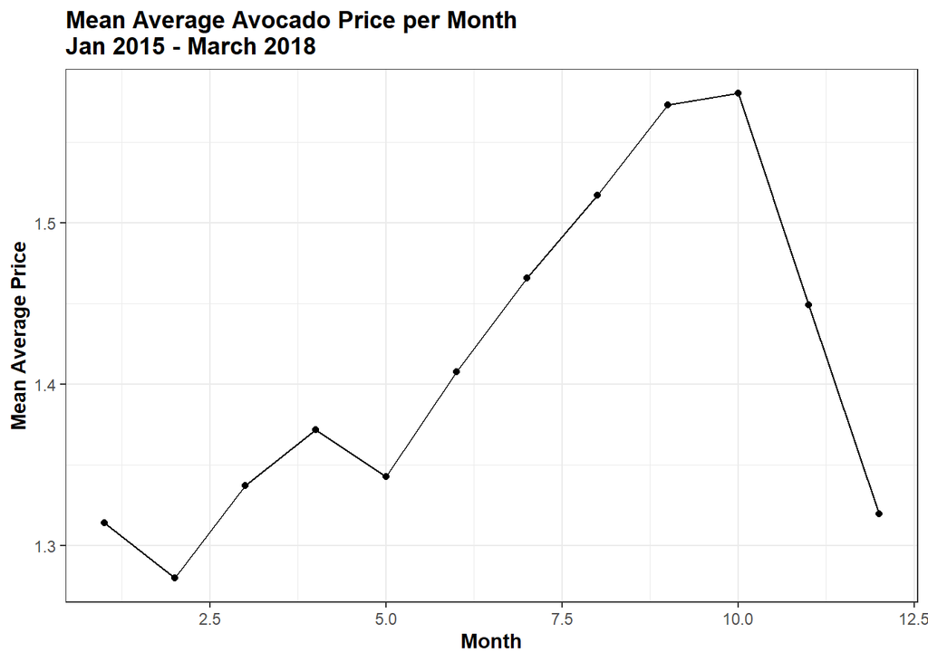

```r
avo_train %>%
  dplyr::select(month, average_price) %>%
  group_by(month) %>%
  summarise(mean_price_per_month = mean(average_price)) %>%
  ggplot() +
  aes(x = month, y = mean_price_per_month) +
  geom_line(group = 1) +
  geom_point() +
  labs(title = "Mean Average Avocado Price per Month\nJan 2015 - March 2018",
       x = "Month",
       y = "Mean Average Price") +
  theme_bw() +
  theme(title = element_text(face = "bold"))
```

This plot suggests that there is indeed some seasonality. It would be worth retaining the `month` column to check in the model later, but there’s no need to keep the level of detail contained in the `date` column. Variation by day is too much detail.

#### Regions

Considering `region`, there are several values that are very ambiguous such as `plains`, `WestTexNewMexico`, `SouthEast`. Although regional variations may be a significant factor worthy of inclusion in a model, it would be difficult to rationally separate all of the areas into discrete constituent states, so region will also be removed.

```r
avo_train <- avo_train %>%
  dplyr::select(-c(date, region))
```

#### Other Considerations

The `x1` column appears to be an identifier of individual observations and will not influence the model, so can be removed safely.

```r
avo_train <- avo_train %>%
  dplyr::select(-x1)
```

It looks likely that there will be aliases in bag sizes;

```r
alias(lm(average_price ~ ., data = avo_train))
```

```
## Model :
## average_price ~ total_volume + x4046 + x4225 + x4770 + total_bags +
##     small_bags + large_bags + x_large_bags + type + year + month
```

The alias function shows nothing at this point, but it looks like `total_bags` = `small_bags` + `large_bags` + `x_large_bags` - verify this a different way, bearing in mind that R is not a perfect calculator when trying to compare floating point numbers;

```r
avo_train %>%
  mutate(bag_check =
           as.integer(total_bags - (small_bags + large_bags + x_large_bags))) %>%
  distinct(bag_check)
```

```
## # A tibble: 3 x 1
##   bag_check
##       <int>
## 1         0
## 2        -1
## 3         1
```

So it looks like the supposition:

`total_bags` = `small_bags` + `large_bags` + `x_large_bags`

is true - R’s lack of precision in performing floating point calculations leads to rounding errors within +/- 1, which is what is shown in the results.

In conclusion, we can safely remove `total_bags` from the data set, because this can be calculated if necessary.

```r
avo_train <- avo_train %>%
  dplyr::select(-total_bags)
```

`x4046`, `x4225` or `x4770` are Price Lookup Codes:

(from https://loveonetoday.com/how-to/identify-hass-avocados/)

The most commonly sold sizes of fresh Hass avocado can be identified by their Price Look Up code or PLU or sticker.

- Small/Medium Hass Avocado (~3-5oz avocado) | #4046 Avocado
- Large Hass Avocado (~8-10oz avocado) | #4225 Avocado
- Extra Large Hass Avocado (~10-15oz avocado) | #4770 Avocado

One last change is to set non-numeric variables as factors for processing;

```r
avo_train <- avo_train %>%
  mutate(type = as.factor(type),
         month = as.factor(month))
```

## First Predictor

Check the remaining variables for signs of correlation in order to determine possible predictors for the model;

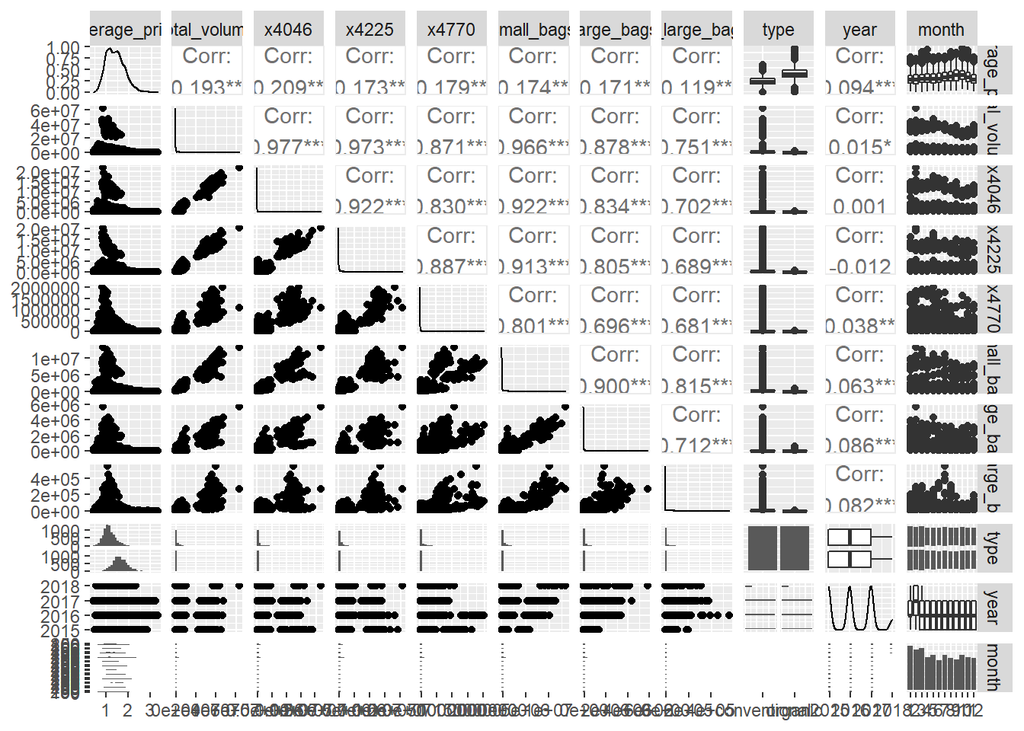

```r
ggpairs(avo_train)
```

## mod1a —-

From the plot it appears as though `type` may be an important factor;

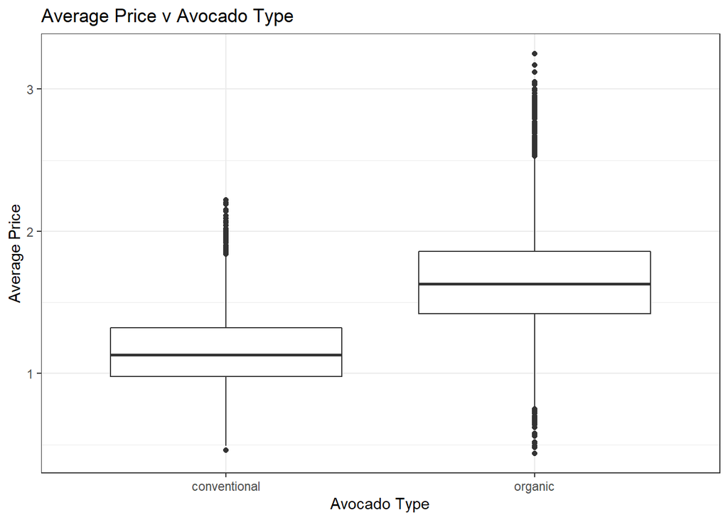

```r
avo_train %>%
  ggplot() +
  aes(x = type, y = average_price) +
  geom_boxplot() +
  theme_bw() +
  labs(title = "Average Price v Avocado Type",
       x = "Avocado Type",
       y = "Average Price")
```

`type` is a categorical variable, so should be checked for significance using ANOVA both with and without `type` included;

```r
anova(lm(average_price ~ . -type, data = avo_train))
```

```
## Analysis of Variance Table
##
## Response: average_price
##                 Df  Sum Sq Mean Sq  F value    Pr(>F)
## total_volume     1   98.71  98.710 700.4420 < 2.2e-16 ***
## x4046            1   23.66  23.657 167.8663 < 2.2e-16 ***
## x4225            1    0.30   0.297   2.1042  0.146917
## x4770            1    5.71   5.706  40.4896 2.029e-10 ***
## small_bags       1    2.75   2.752  19.5279 9.978e-06 ***
## large_bags       1    3.02   3.016  21.3997 3.757e-06 ***
## x_large_bags     1    1.15   1.149   8.1567  0.004296 **
## year             1   21.58  21.582 153.1450 < 2.2e-16 ***
## month           11  176.32  16.029 113.7399 < 2.2e-16 ***
## Residuals    16405 2311.88   0.141
## ---
## Signif. codes:  0 '***' 0.001 '**' 0.01 '*' 0.05 '.' 0.1 ' ' 1
```

```r
anova(lm(average_price ~ ., data = avo_train))
```

```
## Analysis of Variance Table
##
## Response: average_price
##                 Df  Sum Sq Mean Sq    F value    Pr(>F)
## total_volume     1   98.71   98.71  1160.8249 < 2.2e-16 ***
## x4046            1   23.66   23.66   278.2006 < 2.2e-16 ***
## x4225            1    0.30    0.30     3.4872 0.0618632 .
## x4770            1    5.71    5.71    67.1024 2.766e-16 ***
## small_bags       1    2.75    2.75    32.3631 1.301e-08 ***
## large_bags       1    3.02    3.02    35.4651 2.650e-09 ***
## x_large_bags     1    1.15    1.15    13.5179 0.0002371 ***
## type             1  914.25  914.25 10751.5832 < 2.2e-16 ***
## year             1   22.16   22.16   260.5688 < 2.2e-16 ***
## month           11  178.46   16.22   190.7932 < 2.2e-16 ***
## Residuals    16404 1394.90    0.09
## ---
## Signif. codes:  0 '***' 0.001 '**' 0.01 '*' 0.05 '.' 0.1 ' ' 1
```

It looks like type *is* statistically significant. So the first model could be;

```r
mod1a <- lm(average_price ~ type, data = avo_train)
```

How does this look;

```r
summary(mod1a)
```

```
##
## Call:
## lm(formula = average_price ~ type, data = avo_train)
##
## Residuals:
##      Min       1Q   Median       3Q      Max
## -1.21325 -0.19959 -0.02959  0.18675  1.59675
##
## Coefficients:
##             Estimate Std. Error t value Pr(>|t|)
## (Intercept) 1.159591   0.003491  332.21   <2e-16 ***
## typeorganic 0.493662   0.004938   99.97   <2e-16 ***
## ---
## Signif. codes:  0 '***' 0.001 '**' 0.01 '*' 0.05 '.' 0.1 ' ' 1
##
## Residual standard error: 0.3164 on 16423 degrees of freedom
## Multiple R-squared:  0.3783, Adjusted R-squared:  0.3783
## F-statistic:  9994 on 1 and 16423 DF,  p-value: < 2.2e-16
```

This suggests that 37% of the variance in our model could be explained by `type`.

Run the diagnostic plots;

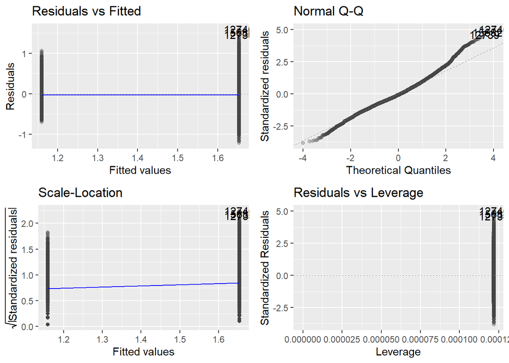

```r
autoplot(mod1a, alpha = 0.3)
```

These look acceptable;

- The Residuals v Fitted are spread around 0 with a fairly flat line
- Q-Q plot is not perfect, but is on the line for the most part
- Scale - Location are in a band above the x-axis with only a very slight funnel effect evident.

## mod1b —-

At the very start it looked like `month` might also be a significant factor due to the seasonality of avocado growth and harvesting;

```r
mod1b <- lm(average_price ~ month, data = avo_train)
```

Check ANOVA with and without `month`;

```r
anova(lm(average_price ~ . -month, data = avo_train))
```

```
## Analysis of Variance Table
##
## Response: average_price
##                 Df  Sum Sq Mean Sq   F value    Pr(>F)
## total_volume     1   98.71   98.71 1029.8451 < 2.2e-16 ***
## x4046            1   23.66   23.66  246.8103 < 2.2e-16 ***
## x4225            1    0.30    0.30    3.0937 0.0786135 .
## x4770            1    5.71    5.71   59.5310 1.273e-14 ***
## small_bags       1    2.75    2.75   28.7114 8.514e-08 ***
## large_bags       1    3.02    3.02   31.4635 2.065e-08 ***
## x_large_bags     1    1.15    1.15   11.9926 0.0005355 ***
## type             1  914.25  914.25 9538.4455 < 2.2e-16 ***
## year             1   22.16   22.16  231.1679 < 2.2e-16 ***
## Residuals    16415 1573.37    0.10
## ---
## Signif. codes:  0 '***' 0.001 '**' 0.01 '*' 0.05 '.' 0.1 ' ' 1
```

```r
anova(mod1b)
```

```
## Analysis of Variance Table
##
## Response: average_price
##              Df  Sum Sq Mean Sq F value    Pr(>F)
## month        11  160.55 14.5954  96.419 < 2.2e-16 ***
## Residuals 16413 2484.51  0.1514
## ---
## Signif. codes:  0 '***' 0.001 '**' 0.01 '*' 0.05 '.' 0.1 ' ' 1
```

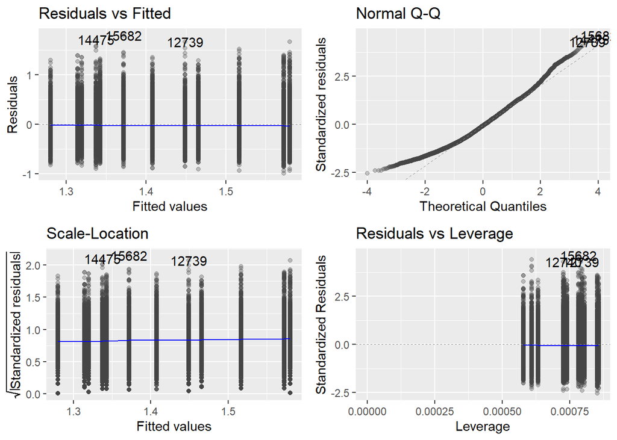

```r
autoplot(mod1b, alpha = 0.3)
```

These don’t look perfect, but once again the residuals v fitted are spread across 0 with a fairy flat line, and the Q-Q plot is on the line for the mid- section of the points.

```r
summary(mod1b)
```

```
##
## Call:
## lm(formula = average_price ~ month, data = avo_train)
##
## Residuals:
##      Min       1Q   Median       3Q      Max
## -0.99285 -0.29710 -0.03003  0.25085  1.79824
##
## Coefficients:
##              Estimate Std. Error t value Pr(>|t|)
## (Intercept)  1.314291   0.009362 140.382  < 2e-16 ***
## month2      -0.034265   0.013547  -2.529   0.0114 *
## month3       0.023194   0.013410   1.730   0.0837 .
## month4       0.057471   0.014359   4.002 6.30e-05 ***
## month5       0.028419   0.014079   2.019   0.0436 *
## month6       0.093541   0.014743   6.345 2.29e-10 ***
## month7       0.151286   0.014129  10.708  < 2e-16 ***
## month8       0.202809   0.014432  14.053  < 2e-16 ***
## month9       0.258557   0.014721  17.564  < 2e-16 ***
## month10      0.265840   0.014062  18.905  < 2e-16 ***
## month11      0.134863   0.014398   9.367  < 2e-16 ***
## month12      0.005323   0.014468   0.368   0.7129
## ---
## Signif. codes:  0 '***' 0.001 '**' 0.01 '*' 0.05 '.' 0.1 ' ' 1
##
## Residual standard error: 0.3891 on 16413 degrees of freedom
## Multiple R-squared:  0.0607, Adjusted R-squared:  0.06007
## F-statistic: 96.42 on 11 and 16413 DF,  p-value: < 2.2e-16
```

It looks like some of the months have a significant effect on average_price, although the overall R-squared is poor. If they are to be included then *all* months will be included.

Double check significance; run an ANOVA against the null model (intercept only);

```r
null_model <- lm(average_price ~ 1, data = avo_train)
month_model <- lm(average_price ~ month, data = avo_train)

anova(null_model, month_model)
```

```
## Analysis of Variance Table
##
## Model 1: average_price ~ 1
## Model 2: average_price ~ month
##   Res.Df    RSS Df Sum of Sq      F    Pr(>F)
## 1  16424 2645.1
## 2  16413 2484.5 11    160.55 96.419 < 2.2e-16 ***
## ---
## Signif. codes:  0 '***' 0.001 '**' 0.01 '*' 0.05 '.' 0.1 ' ' 1
```

So `month` is significant.

## mod1c —-

It would make sense that avocado size would impact on price:

```r
mod1c <- lm(average_price ~ x4046, data = avo_train)
```

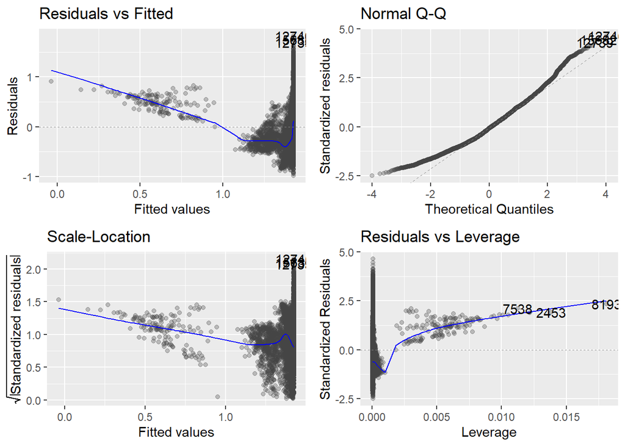

```r
autoplot(mod1c, alpha = 0.3)
```

The diagnostic plots really don’t look acceptable. There are signs of non-normal distribution in every plot.

| Taking the log of `x4046`returned an error; |
| --- |
| Error in lm.fit(x, y, offset = offset, singular.ok = singular.ok, …) : NA/NaN/Inf in ‘x’ |

## mod1d —-

Try `x4225`;

```r
mod1d <- lm(average_price ~ x4225, data = avo_train)
```

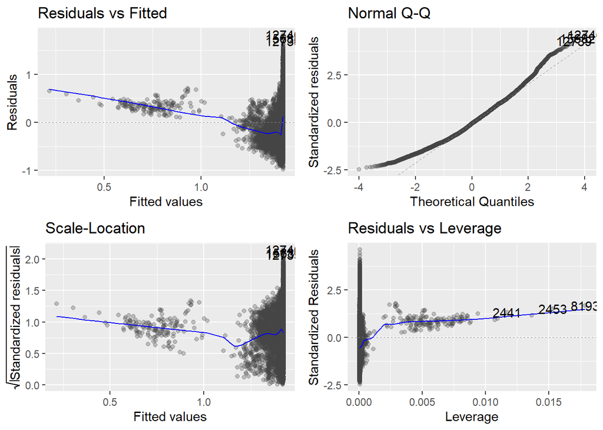

```r
autoplot(mod1d, alpha = 0.3)
```

This is also unacceptable; try `x4770`

## mod1e —-

```r
mod1e <- lm(average_price ~ x4770, data = avo_train)
```

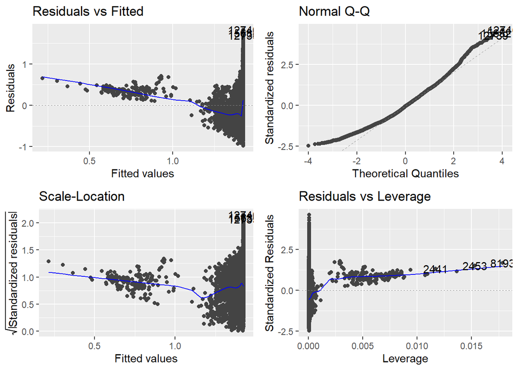

```r
autoplot(mod1d)
```

It looks like avocado size *might* be significant based on the ANOVA results earlier, but they don’t fit the linear model.

## Model 1 —-

So `type` looks like the most promising predictor so far, giving;

```r
avo_model1 <- lm(average_price ~ type, data = avo_train)
```

## Second Predictor

Looking at residuals;

```r
avo_residuals <- avo_train %>%
  add_residuals(mod1a) %>%
  dplyr::select(-c(average_price, type))

avo_residuals_numeric <- avo_residuals %>%
  dplyr::select_if(is.numeric)

avo_residuals_nonnumeric <- avo_residuals %>%
  dplyr::select_if(function(x) !is.numeric(x))

avo_residuals_nonnumeric$resid <- avo_residuals$resid
```

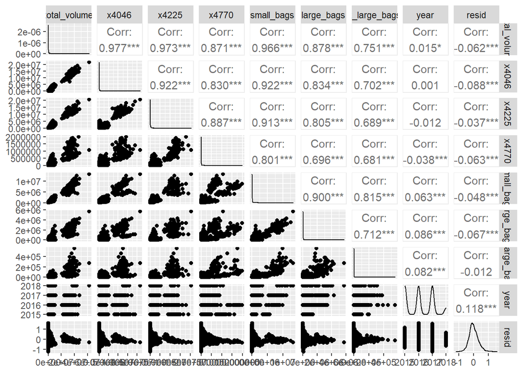

```r
ggpairs(avo_residuals_numeric)
```

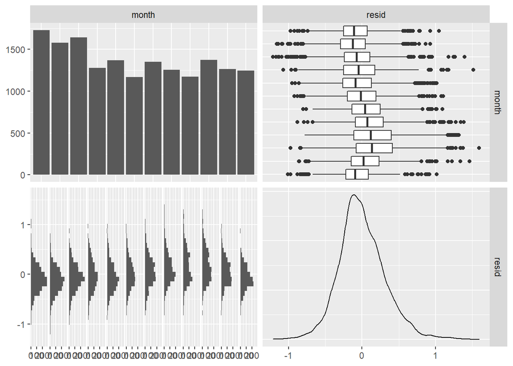

```r
ggpairs(avo_residuals_nonnumeric)
```

Month(as tried in mod1b) looks like it’s the next best against `resid`, although `year` also looks like it might be a factor, having the next highest (albeit low) correlation coefficient with resid.

## mod2a —-

Add month into the model, since the ANOVA above did show significance.

```r
mod2a <- lm(average_price ~ type + month, data = avo_train)
```

```r
summary(mod2a)
```

```
##
## Call:
## lm(formula = average_price ~ type + month, data = avo_train)
##
## Residuals:
##      Min       1Q   Median       3Q      Max
## -1.14799 -0.19690 -0.01908  0.18990  1.54990
##
## Coefficients:
##              Estimate Std. Error t value Pr(>|t|)
## (Intercept)  1.066119   0.007616 139.980  < 2e-16 ***
## typeorganic  0.493203   0.004696 105.027  < 2e-16 ***
## month2      -0.034413   0.010477  -3.285  0.00102 **
## month3       0.022963   0.010371   2.214  0.02684 *
## month4       0.060780   0.011105   5.473 4.48e-08 ***
## month5       0.033773   0.010888   3.102  0.00193 **
## month6       0.093210   0.011402   8.175 3.17e-16 ***
## month7       0.149574   0.010926  13.689  < 2e-16 ***
## month8       0.201039   0.011161  18.013  < 2e-16 ***
## month9       0.258656   0.011384  22.720  < 2e-16 ***
## month10      0.268666   0.010875  24.705  < 2e-16 ***
## month11      0.139358   0.011135  12.515  < 2e-16 ***
## month12      0.015616   0.011190   1.396  0.16285
## ---
## Signif. codes:  0 '***' 0.001 '**' 0.01 '*' 0.05 '.' 0.1 ' ' 1
##
## Residual standard error: 0.3009 on 16412 degrees of freedom
## Multiple R-squared:  0.4383, Adjusted R-squared:  0.4378
## F-statistic:  1067 on 12 and 16412 DF,  p-value: < 2.2e-16
```

The adjusted R-squared indicates that 43% of the variance in our model could be explained by `type` + `month`.

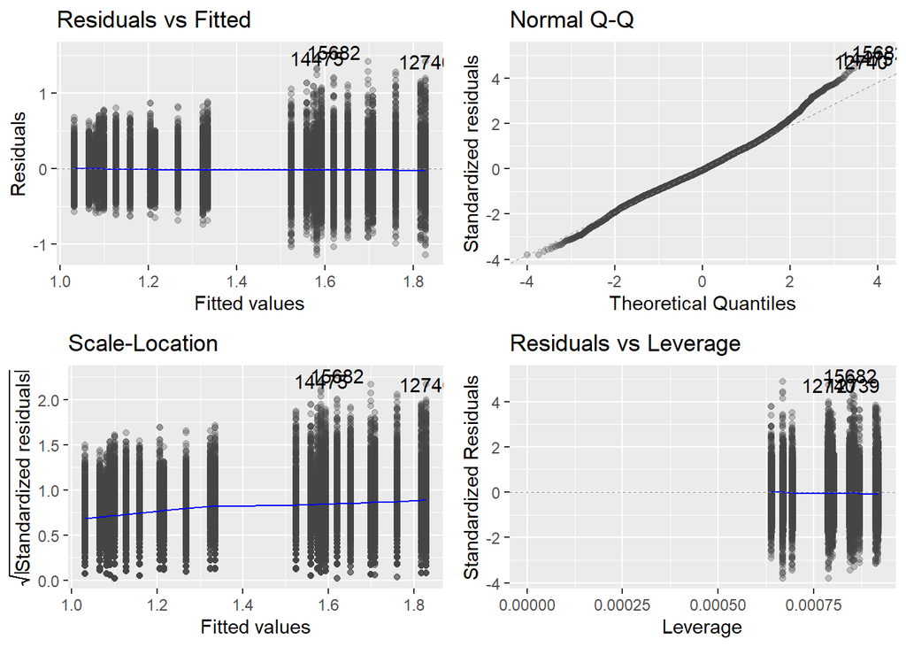

```r
autoplot(mod2a, alpha = 0.3)
```

The diagnostic plots are generally acceptable for this model;

- Fitted v Residuals are spread across 0 with a fairly horizontal line.
- Q-Q plot shows around 75% of the points are on the line
- Scale - Location does not show any extreme funnelling effect

How does this compare with using `year` as the second predictor?

## mod2b —-

```r
mod2b <- lm(average_price ~ type + year, data = avo_train)
```

```r
summary(mod2b)
```

```
##
## Call:
## lm(formula = average_price ~ type + year, data = avo_train)
##
## Residuals:
##      Min       1Q   Median       3Q      Max
## -1.24737 -0.19751 -0.02368  0.18619  1.60249
##
## Coefficients:
##               Estimate Std. Error t value Pr(>|t|)
## (Intercept) -79.210054   5.255939  -15.07   <2e-16 ***
## typeorganic   0.493557   0.004903  100.66   <2e-16 ***
## year          0.039863   0.002607   15.29   <2e-16 ***
## ---
## Signif. codes:  0 '***' 0.001 '**' 0.01 '*' 0.05 '.' 0.1 ' ' 1
##
## Residual standard error: 0.3142 on 16422 degrees of freedom
## Multiple R-squared:  0.3871, Adjusted R-squared:  0.387
## F-statistic:  5185 on 2 and 16422 DF,  p-value: < 2.2e-16
```

This shows that `year` has less of an effect than `month`. Make model 2 with `month`;

## Model 2 —-

```r
avo_model2 <- lm(average_price ~ type + month, data = avo_train)
```

And look at the residuals again;

```r
avo_residuals <- avo_train %>%
  add_residuals(mod1a) %>%
  dplyr::select(-c(average_price, type, month))

avo_residuals_numeric <- avo_residuals %>%
  dplyr::select_if(is.numeric)

avo_residuals_nonnumeric <- avo_residuals %>%
  dplyr::select_if(function(x) !is.numeric(x))

avo_residuals_nonnumeric$resid <- avo_residuals$resid
```

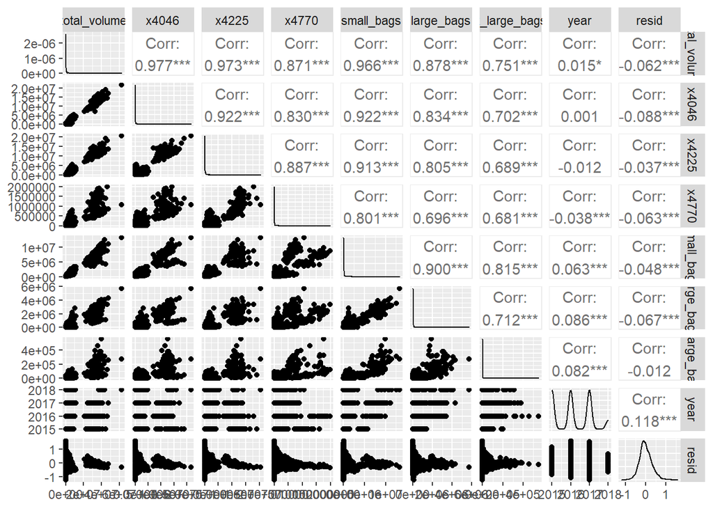

```r
ggpairs((avo_residuals_numeric))
```

This suggests that the best model for average pricing of avocados is model 2.

$$average\_price \sim type + month$$

This indicates that the average price of avocados varies as an approximately linear function of the type of avocado and the month of the year. This seems fairly reasonable.

The analysis also shows that the model can explain around 43% of the variance in avocado average price.

## Model 3: Check for Interactions

The model currently depends on `type` and `month`. Do they show any interactions?

Separate the residuals;

```r
avocado_residuals <- avo_train %>%
  add_residuals(avo_model2) %>%
  dplyr::select(-average_price)
```

Visualise the potential interactions with coplot;

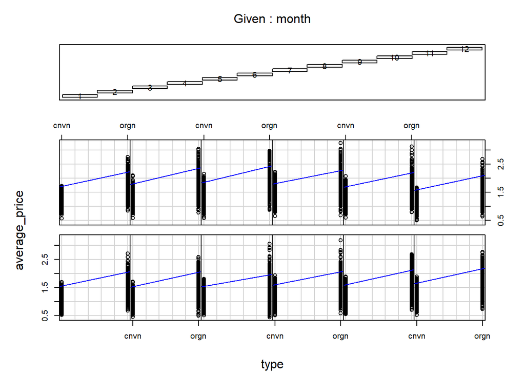

```r
coplot(average_price ~ type | month,
       panel = function(x, y, ...){
         points(x, y)
         abline(lm(y ~ x), col = "blue")
       },
       data = avo_train,
       alpha = 0.3,
       columns = 6)
```

At first glance it looks like there’s no interaction between `type` and `month`. The blue line is pretty constant for all ranges of month.

Check the summary;

```r
avo_model3 <- lm(average_price ~ type + month + type:month, data = avo_train)

summary(avo_model3)
```

```
##
## Call:
## lm(formula = average_price ~ type + month + type:month, data = avo_train)
##
## Residuals:
##      Min       1Q   Median       3Q      Max
## -1.12921 -0.19537 -0.02087  0.18890  1.56913
##
## Coefficients:
##                      Estimate Std. Error t value Pr(>|t|)
## (Intercept)          1.069848   0.010252 104.352  < 2e-16 ***
## typeorganic          0.485790   0.014453  33.612  < 2e-16 ***
## month2              -0.048752   0.014837  -3.286 0.001019 **
## month3               0.061059   0.014689   4.157 3.24e-05 ***
## month4               0.076015   0.015664   4.853 1.23e-06 ***
## month5               0.021187   0.015326   1.382 0.166838
## month6               0.083070   0.016151   5.143 2.73e-07 ***
## month7               0.143615   0.015502   9.264  < 2e-16 ***
## month8               0.167227   0.015837  10.559  < 2e-16 ***
## month9               0.219911   0.016118  13.644  < 2e-16 ***
## month10              0.283523   0.015350  18.471  < 2e-16 ***
## month11              0.137230   0.015685   8.749  < 2e-16 ***
## month12              0.004670   0.015657   0.298 0.765497
## typeorganic:month2   0.028484   0.020913   1.362 0.173213
## typeorganic:month3  -0.075634   0.020703  -3.653 0.000260 ***
## typeorganic:month4  -0.030786   0.022167  -1.389 0.164915
## typeorganic:month5   0.025399   0.021736   1.169 0.242607
## typeorganic:month6   0.020135   0.022760   0.885 0.376363
## typeorganic:month7   0.011812   0.021812   0.542 0.588134
## typeorganic:month8   0.066772   0.022280   2.997 0.002731 **
## typeorganic:month9   0.077026   0.022725   3.389 0.000702 ***
## typeorganic:month10 -0.029952   0.021708  -1.380 0.167689
## typeorganic:month11  0.004172   0.022228   0.188 0.851134
## typeorganic:month12  0.022375   0.022344   1.001 0.316655
## ---
## Signif. codes:  0 '***' 0.001 '**' 0.01 '*' 0.05 '.' 0.1 ' ' 1
##
## Residual standard error: 0.3003 on 16401 degrees of freedom
## Multiple R-squared:  0.4408, Adjusted R-squared:   0.44
## F-statistic: 562.1 on 23 and 16401 DF,  p-value: < 2.2e-16
```

It looks like there is a very small increase in adjusted r-squared when the interaction is included; from 43% to 44%, which would give the best fit model as;

$$average\_price \sim type + month + type:month$$

What are the relative importances of the model constituents;

```r
calc.relimp(avo_model3, type = "lmg", rela = TRUE)
```

```
## Response variable: average_price
## Total response variance: 0.1610487
## Analysis based on 16425 observations
##
## 23 Regressors:
## Some regressors combined in groups:
##         Group  month : month2 month3 month4 month5 month6 month7 month8 month9 month10 month11 month12
##         Group  type:month : typeorganic:month2 typeorganic:month3 typeorganic:month4 typeorganic:month5 typeorganic:month6 typeorganic:month7 typeorganic:month8 typeorganic:month9 typeorganic:month10 typeorganic:month11 typeorganic:month12
##
##  Relative importance of 3 (groups of) regressors assessed:
##  month type:month type
##
## Proportion of variance explained by model: 44.08%
## Metrics are normalized to sum to 100% (rela=TRUE).
##
## Relative importance metrics:
##
##                    lmg
## month      0.136822983
## type:month 0.005780117
## type       0.857396900
##
## Average coefficients for different model sizes:
##
##                          1group     2groups      3groups
## type                 0.49366218  0.49320278  0.485790180
## month2              -0.03426534 -0.03441257 -0.048751546
## month3               0.02319410  0.02296260  0.061059491
## month4               0.05747126  0.06077996  0.076014657
## month5               0.02841933  0.03377282  0.021187486
## month6               0.09354137  0.09321027  0.083070341
## month7               0.15128625  0.14957380  0.143614784
## month8               0.20280892  0.20103922  0.167227444
## month9               0.25855672  0.25865581  0.219911378
## month10              0.26584023  0.26866637  0.283523440
## month11              0.13486347  0.13935831  0.137229640
## month12              0.00532347  0.01561642  0.004670149
## typeorganic:month2          NaN         NaN  0.028483950
## typeorganic:month3          NaN         NaN -0.075634069
## typeorganic:month4          NaN         NaN -0.030785814
## typeorganic:month5          NaN         NaN  0.025399368
## typeorganic:month6          NaN         NaN  0.020134532
## typeorganic:month7          NaN         NaN  0.011812245
## typeorganic:month8          NaN         NaN  0.066772256
## typeorganic:month9          NaN         NaN  0.077026228
## typeorganic:month10         NaN         NaN -0.029951579
## typeorganic:month11         NaN         NaN  0.004171695
## typeorganic:month12         NaN         NaN  0.022374520
```

This shows that 86% of the r-squared value is made up of `type`, 13% is `month` and the interaction component only makes up 0.5%. In the interest of simplicity it would probably be safe to remove the interaction, but the significance of this could be checked with BIC;

```r
BIC(avo_model2)
```

```
## [1] 7281.78
```

```r
BIC(avo_model3)
```

```
## [1] 7313.884
```

Based on the BIC values, avo_model2 would be the best (without interaction):

$$average\_price \sim type + month$$

## Run the Test Set

Now try the test set on the model. The test set needs to be updated to include the month column to allow the model to run;

```r
avo_test <- avo_test %>%
   mutate(month = month(as.POSIXlt(date), label = TRUE, abbr = TRUE)) %>%
   mutate(type = as.factor(type),
         month = as.factor(month))
```

```r
avo_model_test <- lm(average_price ~ type + month, data = avo_test)
```

```r
summary(avo_model_test)
```

```
##
## Call:
## lm(formula = average_price ~ type + month, data = avo_test)
##
## Residuals:
##      Min       1Q   Median       3Q      Max
## -0.95320 -0.19550 -0.03285  0.17731  1.31680
##
## Coefficients:
##              Estimate Std. Error t value Pr(>|t|)
## (Intercept)  1.153769   0.010342 111.564  < 2e-16 ***
## typeorganic  0.518355   0.014523  35.692  < 2e-16 ***
## month.L      0.257782   0.024449  10.544  < 2e-16 ***
## month.Q     -0.165569   0.024389  -6.789 1.53e-11 ***
## month.C     -0.176218   0.024761  -7.117 1.59e-12 ***
## month^4     -0.041151   0.024657  -1.669   0.0953 .
## month^5     -0.038182   0.025417  -1.502   0.1332
## month^6      0.057925   0.026040   2.224   0.0262 *
## month^7     -0.011788   0.025236  -0.467   0.6405
## month^8      0.014779   0.025344   0.583   0.5599
## month^9     -0.003314   0.026243  -0.126   0.8995
## month^10    -0.052520   0.026164  -2.007   0.0449 *
## month^11     0.024767   0.025888   0.957   0.3389
## ---
## Signif. codes:  0 '***' 0.001 '**' 0.01 '*' 0.05 '.' 0.1 ' ' 1
##
## Residual standard error: 0.308 on 1811 degrees of freedom
## Multiple R-squared:  0.4525, Adjusted R-squared:  0.4489
## F-statistic: 124.7 on 12 and 1811 DF,  p-value: < 2.2e-16
```

This gives an adjusted r-squared of 45%, which corresponds well with what the result was for the training set (43%). The fact that the test set is a better fit also indicates that there’s no excessive overfitting.

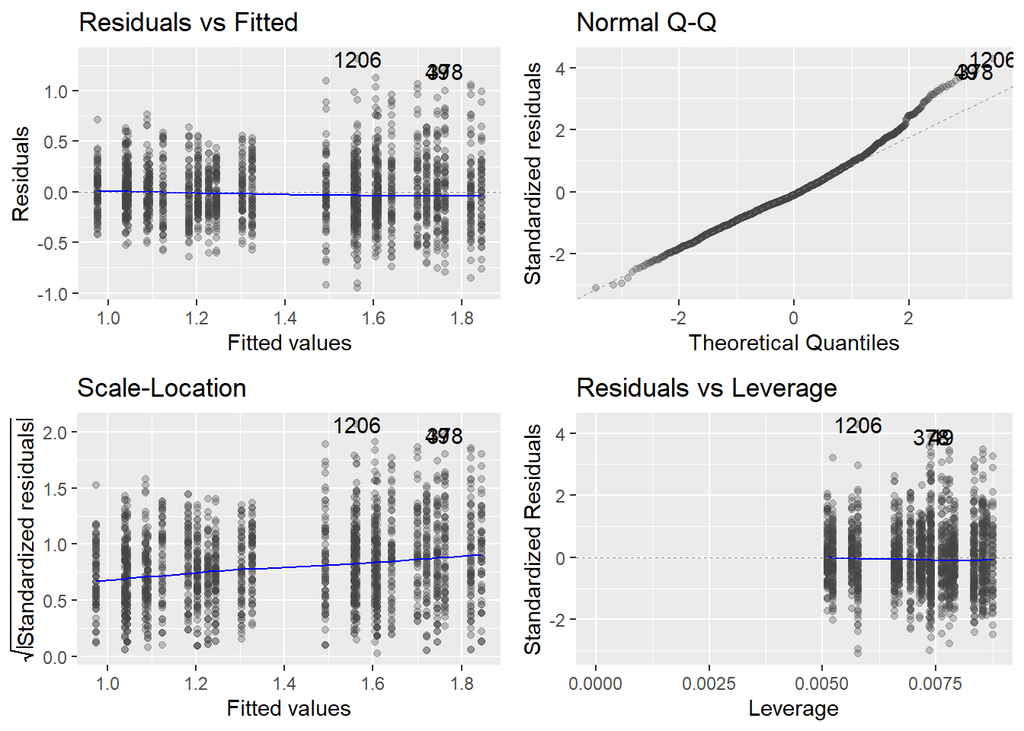

```r
autoplot(avo_model_test, alpha = 0.3)
```

Again these plots look acceptable.

- Residuals v Fitted shows a spread across 0 with a relatively horizontal line
- Normal Q-Q shows around 75% of points are on the line
- Scale - Location shows minimal funnelling

## Summary

Through the analysis detailed above the following conclusions can be drawn;

- The data set was tidied in several ways, namely
  - date was changed from day granularity to month
  - region was discounted due to insufficient clarification of general regional areas such as `plains`, `WestTexNewMexico`and `SouthEast`
- The model was manually developed using a test-train split
- The best fit model found for the average price of avocados gave an adjusted r-squared of 45% with the test data and was defined as;

$$average\_price \sim type + month$$

- An interaction between `type` and `month` was found, but was very small (0.5% of total r-squared) and was removed after comparing the BIC on models with and without the interaction
- This model was found to perform equally well on the test data as on the training data, with no evidence of overfitting